# Bioinformatic analyses of plasmid-borne RsmA

jpjh November 2021

### 1. Identification of RsmA homologues from plasmids in databases

Questions:

- What plasmids are RsmA homologues on?
- What are the sequences of these genes?
- What kinds of plasmids are these sequences on?

COMPASS plasmid database was annotated using [PROKKA](https://github.com/tseemann/prokka), with default settings. PROKKA uses UniProtKB (SwissProt) databases to annotate.

Link to annotation in `./ref/COMPASS_prokka.gff` and `./ref/COMPASS_prokka.faa`.

```bash
grep "CsrA" ./ref/COMPASS_prokka.gff | wc -l # 95
grep "[Cc]arbon storage regulator" ./ref/COMPASS_prokka.gff | wc -l # 11
```

This gives us our list of CsrA-like genes in COMPASS. Need to match these up with the overall COMPASS metadata to get a table with plasmid details and CsrA sequence.

```bash
grep "CsrA" ./ref/COMPASS_prokka.faa \
  | sed 's/>//g' > ./working/COMPASS_CsrA_matches.txt

grep "[Cc]arbon storage regulator" ./ref/COMPASS_prokka.faa  \
  | sed 's/>//g' >> ./working/COMPASS_CsrA_matches.txt

seqtk subseq ./ref/COMPASS_prokka.faa \
  ./working/COMPASS_CsrA_matches.txt \
  | awk '{print $1}' \
  | tr '\n' '\t' | tr '>' '\n' \
  > ./working/COMPASS_CsrA_matches.tsv

seqtk subseq ./ref/COMPASS_prokka.ffn \
  ./working/COMPASS_CsrA_matches.txt \
  | awk '{print $1}' \
  | tr '\n' '\t' | tr '>' '\n' \
  > ./working/COMPASS_CsrA_matches_na.tsv

grep "CsrA" ./ref/COMPASS_prokka.gff \
  > ./working/COMPASS_prokka_CsrA_matches.gff

grep "[Cc]arbon storage regulator" ./ref/COMPASS_prokka.gff \
  >> ./working/COMPASS_prokka_CsrA_matches.gff
```

Load into R and join with plasmid details.

Note: using the full table from COMPASS to join, which probably results in some duplicates.

```r
# Note: eval is set to FALSE as a workaround to deal with the fact
#    that Rmarkdown doesn't work with symbolic links.
# These files were manually loaded into R.

source("./func/gff_functions.R")

comp <- read.csv("./ref/COMPASS.csv", row.names = NULL, sep=";")
dups <- read.csv("./ref/COMPASS_duplicates_by_accession.txt", header=FALSE)

gff <- gffRead("./working/COMPASS_prokka_CsrA_matches.gff")

csra_seqs <- read.table("./working/COMPASS_CsrA_matches.tsv",
                        col.names=c("ID","seq"))
```

Make some diagnostic plots.

```r
compass <- filter(comp, !(Accession %in% dups$V1))

csra_gff <- data.frame(Accession = gff$seqname,
                       start = gff$start,
                       end = gff$end,
                       strand = gff$strand,
                       ID = getAttributeField(gff$attributes, "ID"))

# Note: using the full table from COMPASS to join, which probably results in some duplicates.

plasmid_csra <- csra_gff %>% left_join(csra_seqs, by="ID") %>%
  left_join(comp, by="Accession")

plasmid_csra %>% filter(duplicated(seq)) %>% nrow() # 55 sequences are identical to others in the database at the AA level
```

```
## [1] 55
```

```r
# are these duplications within Genus, or are there duplicates in different Genera?

plasmid_csra %>% group_by(seq, Genus) %>% count() %>% filter(duplicated(seq)) %>% nrow()
```

```
## [1] 0
```

```r
# All duplicates are duplicated within Genus.

plasmid_csra <- plasmid_csra %>% mutate(Duplicated = factor(ifelse(duplicated(seq), "Y", "N"),
                                                            levels=c("Y","N")))
```

The NA is a Xanthomondales bacterium, [*Ahniella afigens*](https://www.ncbi.nlm.nih.gov/Taxonomy/Browser/wwwtax.cgi?id=2021234) (Rhodanobacteriaceae).

```r
plasmid_csra %>% filter(is.na(Genus))
```

```
##       Accession  start    end strand              ID                                                     seq
## 1 NZ_CP027861.1 146830 146997      - compass_1329038 MLILKRRIEECIQIKVPGQDPILVTILKIVDGHVEVGIDAPRTVEVRRAQKDHTK
##                                                        Description Topology Size..bp.         Phylum
## 1 Xanthomonadales bacterium D13 plasmid unnamed, complete sequence circular    149386 Proteobacteria
##                 Class           Order Family Genus                       Species Plasmid Strain Collection.date
## 1 Gammaproteobacteria Xanthomonadales   <NA>  <NA> Xanthomonadales bacterium D13 unnamed    D13         juil-15
##                  Country REP.types MOB.types MPF.types OriT.types Predicted.Mobility Duplicated
## 1 South Korea: Shnan-gun      <NA>      <NA>      <NA>       <NA>    Non-mobilizable          N
```

```r
compass[compass$Accession=="NZ_CP027861.1",
        c("Family","Genus")] <- c("Rhodanobacteraceae","Ahniella")

plasmid_csra[plasmid_csra$Accession=="NZ_CP027861.1",
             c("Family","Genus")] <- c("Rhodanobacteraceae","Ahniella")
```

Plot CsrA homologues across Genera.

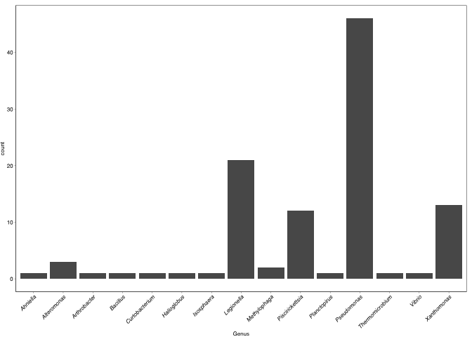

```r
ggplot(data=plasmid_csra, aes(x=Genus)) + geom_bar() + theme_pub() +
  theme(axis.text.x = element_text(face="italic", angle=45, hjust=1))
```

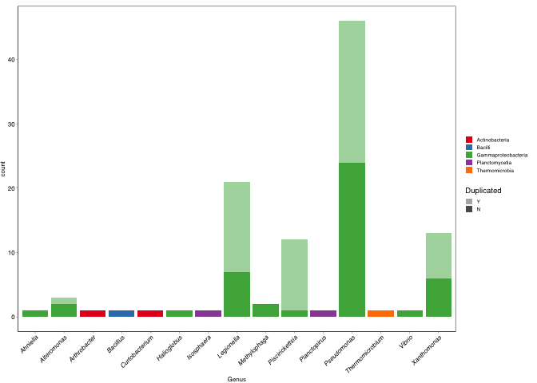

```r
(plot_bar_Class <- ggplot(data=plasmid_csra, aes(x=Genus, fill=Class, alpha=Duplicated)) + geom_bar() +
  scale_fill_brewer(type="qual", palette=6, name="") +
  scale_alpha_manual(values=c(0.5,1)) + theme_pub() +
  theme(axis.text.x = element_text(face="italic", angle=45, hjust=1), legend.position="right"))
```

```r
png(filename="../figs/1_bar_by_genus.png", height=3, width=3, units="in", res=300)
plot_bar_Class
dev.off()
```

Shows >50% come from Gammaproteobacteria, and about 50% have at least one duplicate at the amino-acid level in the database.

How does this compare with plasmid size and other features? Plot CsrA-containing plasmids onto a density plot for each Family. For this, remove the duplicates, because they can confuse the density plot, and remove all Families with <20 plasmids.

```r
compass <- compass %>% mutate(encodes_csra = ifelse(Accession %in% plasmid_csra$Accession, "Y", "N"))

csra_families <- plasmid_csra$Family %>% unique()

compass_subset_fam <- filter(compass, Family %in% csra_families)

(counts_family <- compass_subset_fam %>% group_by(Family, encodes_csra) %>%
    summarise(total = n()) %>% pivot_wider(names_from=encodes_csra, values_from=total, values_fill=0) %>%
  mutate(totals = N + Y))
```

```
## # A tibble: 14 × 4
## # Groups:   Family [14]
##    Family                  N     Y totals
##    <chr>               <int> <int>  <int>
##  1 Alteromonadaceae       15     3     18
##  2 Bacillaceae           616     1    617
##  3 Halieaceae              3     1      4
##  4 Isosphaeraceae          5     1      6
##  5 Legionellaceae         12    18     30
##  6 Microbacteriaceae      22     1     23
##  7 Micrococcaceae         58     1     59
##  8 Piscirickettsiaceae    58    14     72
##  9 Planctomycetaceae       4     1      5
## 10 Pseudomonadaceae      155    41    196
## 11 Rhodanobacteraceae      0     1      1
## 12 Thermomicrobiaceae      0     1      1
## 13 Vibrionaceae          167     1    168
## 14 Xanthomonadaceae      169     8    177
```

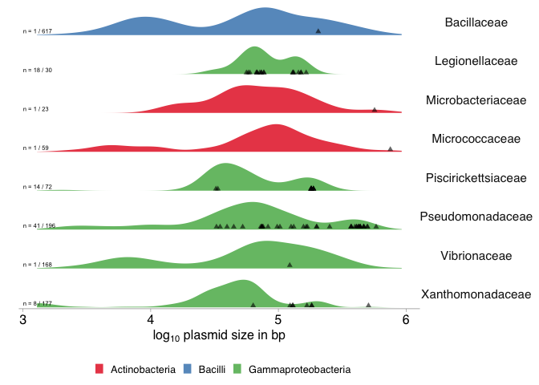

```r
counts_family_20 <- filter(counts_family, totals>20)

compass_subset_fam_20 <- filter(compass_subset_fam,
                             Family %in% counts_family_20$Family)

(plot_joy_family <- ggplot(compass_subset_fam_20, aes(x=log10(Size..bp.))) +
  geom_density(size=0, aes(fill=Class), alpha=0.8) +
  scale_fill_brewer(type="qual", palette=6, name="") +
  geom_point(data=subset(compass_subset_fam_20, encodes_csra=="Y"), y=0.1,
             shape=17, alpha=0.6, colour="black") +
  expand_limits(y=c(0,0.5)) +
  facet_grid(Family~., scales="free_y") +
  geom_text(data=counts_family_20, x=3, y=0, hjust=0, vjust=-0.5, aes(label=paste("n = ", Y, " / ", totals, sep="")), size=2) +
  labs(x=expression(paste("log"[10], " plasmid size in bp")), y="") +
  theme(axis.line.y = element_blank(), axis.text.y = element_blank(),
        panel.border = element_blank(), axis.ticks.y = element_blank(), legend.position="bottom"))
```

```r
png(filename="../figs/2_distribution_family.png", height=6, width=6, units="in", res=300)
plot_joy_family
dev.off()
```

Are there any correlations between CsrA and mobility?

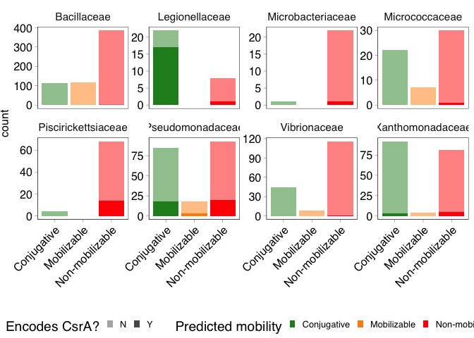

```r
(mobility_csra <- ggplot(data=compass_subset_fam_20, aes(alpha=encodes_csra, fill=Predicted.Mobility, x=Predicted.Mobility)) +
  scale_alpha_manual(values=c(0.5,1), name="Encodes CsrA?") +
  scale_fill_manual(values=c("forestgreen","darkorange","red"), name="Predicted mobility") +
  labs(x="") +
  facet_wrap(~Family, scales="free_y", ncol=4) +
  geom_bar() + theme(legend.position="bottom", axis.text.x=element_text(angle=45, hjust=1)))
```

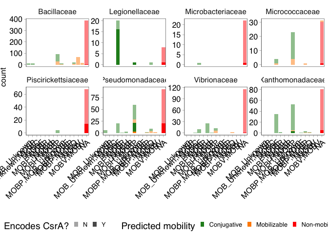

```r
(mobtype_csra <- ggplot(data=compass_subset_fam_20, aes(alpha=encodes_csra, fill=Predicted.Mobility, x=MOB.types)) +
  scale_alpha_manual(values=c(0.5,1), name="Encodes CsrA?") +
  scale_fill_manual(values=c("forestgreen","darkorange","red"), name="Predicted mobility") +
  labs(x="") +
  facet_wrap(~Family, scales="free_y", ncol=4) +
  geom_bar() + theme(legend.position="bottom", axis.text.x=element_text(angle=45, hjust=1)))
```

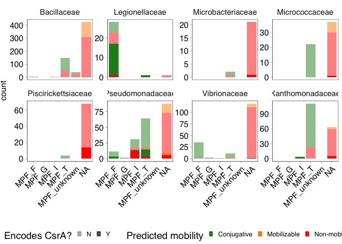

```r
(mpftype_csra <- ggplot(data=compass_subset_fam_20, aes(alpha=encodes_csra, fill=Predicted.Mobility, x=MPF.types)) +
  scale_alpha_manual(values=c(0.5,1), name="Encodes CsrA?") +
  scale_fill_manual(values=c("forestgreen","darkorange","red"), name="Predicted mobility") +
  labs(x="") +
  facet_wrap(~Family, scales="free_y", ncol=4) +
  geom_bar() + theme(legend.position="bottom", axis.text.x=element_text(angle=45, hjust=1)))
```

```r
png(filename="../figs/2_mobility_csra.png", height=3, width=4, units="in", res=300)
mobility_csra
dev.off()
```

No obvious patterns – conjugative plasmids in Legionella may be more likely to have CsrA than Non-Mobilizable, but these pattenrs are not reproduced in other Genera and are more likely to be due to differential sampling within Legionellaceae.

```r
(compass_totals <- compass %>% group_by(Family) %>% count() %>% arrange(-n))
```

```
## # A tibble: 191 × 2
## # Groups:   Family [191]
##    Family                 n
##    <chr>              <int>
##  1 Enterobacteriaceae  3621
##  2 Bacillaceae          617
##  3 Lactobacillaceae     527
##  4 Borreliaceae         503
##  5 Staphylococcaceae    471
##  6 Rhodobacteraceae     382
##  7 Moraxellaceae        372
##  8 Rhizobiaceae         361
##  9 Streptococcaceae     244
## 10 Enterococcaceae      232
## # … with 181 more rows
```

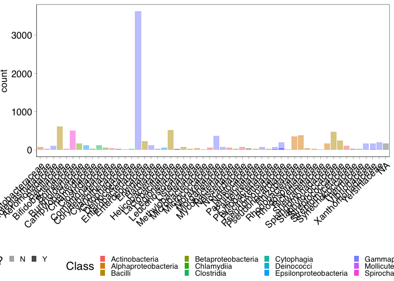

```r
counts_compass_family_20 <- filter(compass_totals, n>20)

(compass_all_family_csra <- compass %>% filter(Family %in% counts_compass_family_20$Family) %>%
  ggplot(aes(alpha=encodes_csra, fill=Class, x=Family)) +
  scale_alpha_manual(values=c(0.5,1), name="Encodes CsrA?") +
  labs(x="") +
  geom_bar() + theme(legend.position="bottom", axis.text.x=element_text(angle=45, hjust=1)))
```

```r
library(patchwork)

png(filename="../figs/3_all_family.png", height=6, width=6, units="in", res=300)
(compass_all_family_csra + theme(axis.text.x=element_blank(), legend.position="none"))  /
  (compass_all_family_csra + coord_cartesian(ylim=c(0,200)))
dev.off()
```

### Analysis of diversity of plasmids encoding CsrA

Calculated MASH distances for all plasmids in COMPASS.

```bash
mash sketch ./ref/COMPASS.fasta -i -S 42 -s 1000 -k 21 -p 4 -o ./ref/COMPASS.msh
mash triangle ./ref/COMPASS.msh -i -k 21 -p 4 > ./ref/COMPASS_mash.dst
```

```r
mash_dist <- read.table("./ref/COMPASS_mash.dst", skip=1,
                        fill = TRUE, col.names=c("V0",paste("V", 1:12084, sep="")))
mash_dist <- column_to_rownames(mash_dist, "V0")

write.table(mash_dist, file = "./ref/COMPASS_mash.mat",
            row.names=FALSE, col.names=FALSE, quote=FALSE)

distmat <- as.dist(mash_dist, upper=TRUE, diag=TRUE)
sqmat <- as.matrix(distmat)

write.table(sqmat, file = "./ref/COMPASS_mash.sqmat",
            quote=FALSE)
```

Cluster with UMAP.

Note on how [Galeta et al.](https://pubmed.ncbi.nlm.nih.gov/30380090/) made their plot:

> First, pairwise distances between the sequences were computed from the created Mash sketches. Then, UMAP was applied to the distance matrix using parameters n_neighbors=50, n_components=2, init=‘random’, metric=‘precomputed’.

Activated `umap_env` in Conda, and then activated Python3.

```python
import numpy as np
from sklearn.datasets import load_digits
from sklearn.model_selection import train_test_split
from sklearn.preprocessing import StandardScaler
import matplotlib.pyplot as plt
import seaborn as sns
import pandas as pd

import umap

reducer = umap.UMAP(n_neighbors=50, n_components=2, init='random', metric='precomputed')

distmat = pd.read_csv('./ref/COMPASS_mash.sqmat', sep=' ', header=0, index_col=0)

embedding = reducer.fit_transform(distmat)

output=pd.DataFrame(data={'Accession': distmat.index.values, 'x':embedding[:,0], 'y':embedding[:,1]})

output.to_csv("./ref/COMPASS_mash_UMAP.csv")
```

Load into R and plot.

```r
# again, load this item before knitting the Rmarkdown as the csv is a symbolic link

compass_mash_UMAP_ <- read.csv("./ref/COMPASS_mash_UMAP.csv",
                              row.names=1)
```

```r
families_to_highlight <- c(unique(compass_subset_fam$Family))

compass_mash_UMAP <- compass_mash_UMAP_ %>%
  left_join(select(compass, Accession, Order, Family, Plasmid, Size..bp.)) %>%
  arrange(Family) %>%
  mutate(encodes_csra = ifelse(Accession %in% plasmid_csra$Accession, "Y", "N"),
         fam_highlight = factor(ifelse(Family %in% families_to_highlight,
                                Family, "Other"), levels=c(families_to_highlight,"Other")))
library(scales)
```

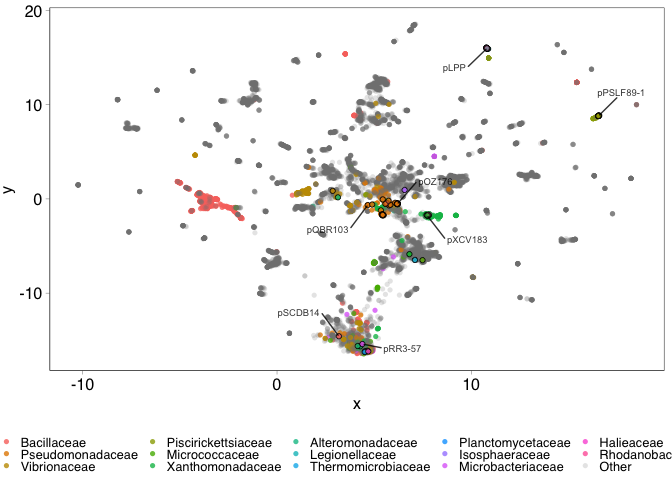

```r
library(ggrepel)

(family_umap <- ggplot(data=compass_mash_UMAP, aes(x=x, y=y, colour=fam_highlight, alpha=fam_highlight)) +
  geom_point(shape=16) +
  scale_alpha_manual(values=c(rep(0.8, length(families_to_highlight)), 0.2), name="") +
  scale_colour_manual(values=c(hue_pal()(length(families_to_highlight)), "grey50"), name="") +
  geom_point(data=subset(compass_mash_UMAP, encodes_csra=="Y"),
             aes(fill=fam_highlight),
             shape=21, colour="black", show.legend = FALSE) +
  geom_text_repel(data=subset(compass_mash_UMAP,
                              Accession %in% c("AM235768.1","NC_022344.1","NC_006365.1",
                                               "NZ_CP011850.1","NC_007507.1","NZ_CP019045.1",
                                               "NZ_CP014843.1")),
                  aes(label=Plasmid), colour="black", box.padding = 1, max.overlaps = Inf, size=2.5, show.legend=FALSE) +
  theme(legend.position="bottom"))
```

```r
png(filename="../figs/4_family_umap.png", height=5, width=5, units="in", res=300)
family_umap
dev.off()
```

This plot shows that CsrA-containing plasmids are diverse, and are often more closely-related to non-CsrA-containing plasmids than other CsrA-containing plasmids, consistent with a model in which there is a prolonged association between CsrA and plasmids, and/or that plasmids are independently/convergently acquiring CsrA.

**Back to index.**